# IST 652 - Scripting for Data Analysis

# Airbnb Price Analysis and Prediction - U.S. Markets

This program analyzes merged Airbnb data from 2020 and 2023, along with Consumer Price Index (CPI) data in JSON format, to address four key research questions:

1. Price forecasting, for future Airbnb prices across key markets.
2. Summary analysis of pricing patterns across different property characteristics with economic indicators.
3. Categorical analysis of listings by temporal periods and geographic regions.
4. Comparative analysis between different market segments and time periods.

Author: Brian Lee, Robin Nightingale, Hector Pena, Natajah Roberts

Data Source: Airbnb listings data (2020 & 2023) merged with Federal Reserve CPI data """

# Exploratory Data Analysis

```python
pip install fredapi
```

```python
import fredapi as fa
import pandas as pd
```

```python
fred = fa.Fred('41e544dc90b02736ed499a799eb36b50') #Using API Key
```

```python
# Get CPI data
cpi = fred.get_series('CPIAUCSL')
print("Last 5 CPI observations:")
print(cpi.tail())
```

```
Last 5 CPI observations:
2024-12-01    317.603
2025-01-01    319.086
2025-02-01    319.775
2025-03-01    319.615
2025-04-01    320.321
dtype: float64
```

```python
#convert to datframe
cpi_df = pd.DataFrame(cpi, columns=['CPI'])
print("\nCPI DataFrame:")
print(cpi_df.head())
```

```
CPI DataFrame:
              CPI
1947-01-01  21.48
1947-02-01  21.62
1947-03-01  22.00
1947-04-01  22.00
1947-05-01  21.95
```

```python
# Reset index to make date a column
cpi_df = cpi_df.reset_index()
cpi_df = cpi_df.rename(columns={'index': 'Date', 'CPI': 'CPI_Value'})
cpi_df.head()
```

|  | Date | CPI_Value |
| --- | --- | --- |
| 0 | 1947-01-01 | 21.48 |
| 1 | 1947-02-01 | 21.62 |
| 2 | 1947-03-01 | 22.00 |
| 3 | 1947-04-01 | 22.00 |
| 4 | 1947-05-01 | 21.95 |

```python
# Create Year-Month column for merge with airbnb dataset
cpi_df['Year-Month'] = cpi_df['Date'].dt.strftime('%Y-%m')
cpi_df.head()
```

|  | Date | CPI_Value | Year-Month |
| --- | --- | --- | --- |
| 0 | 1947-01-01 | 21.48 | 1947-01 |
| 1 | 1947-02-01 | 21.62 | 1947-02 |
| 2 | 1947-03-01 | 22.00 | 1947-03 |
| 3 | 1947-04-01 | 22.00 | 1947-04 |
| 4 | 1947-05-01 | 21.95 | 1947-05 |

```python
#Initial cpi dataset
cpi_df.shape
```

```
(940, 3)
```

```python
# Create Year column to filter to 2020 and 2023 only
cpi_df['Year'] = cpi_df['Date'].dt.year
cpi_df.head()
```

|  | Date | CPI_Value | Year-Month | Year |
| --- | --- | --- | --- | --- |
| 0 | 1947-01-01 | 21.48 | 1947-01 | 1947 |
| 1 | 1947-02-01 | 21.62 | 1947-02 | 1947 |
| 2 | 1947-03-01 | 22.00 | 1947-03 | 1947 |
| 3 | 1947-04-01 | 22.00 | 1947-04 | 1947 |
| 4 | 1947-05-01 | 21.95 | 1947-05 | 1947 |

```python
# filter for years 2020 and 2023 only
filtered_df = cpi_df[cpi_df['Year'].isin([2020, 2023])]
cpi_df = filtered_df
cpi_df.shape
cpi_df.info()
```

```
<class 'pandas.core.frame.DataFrame'>
Index: 24 entries, 876 to 923
Data columns (total 4 columns):
 #   Column      Non-Null Count  Dtype
---  ------      --------------  -----
 0   Date        24 non-null     datetime64[ns]
 1   CPI_Value   24 non-null     float64
 2   Year-Month  24 non-null     object
 3   Year        24 non-null     int32
dtypes: datetime64[ns](1), float64(1), int32(1), object(1)
memory usage: 864.0+ bytes
```

```python
cpi_df.columns
```

```
Index(['Date', 'CPI_Value', 'Year-Month', 'Year'], dtype='object')
```

```python
#CPI cleaned dataset
cpi_df.shape
```

```
(24, 4)
```

```python
pip install --upgrade openpyxl
```

```python
##Airbnb Dataset
# Load Airbnb data
infile = open('ARBNB_US_2020_2023.xlsx', 'rb')
airbnb_df = pd.read_excel(infile, engine='openpyxl')
```

```python
airbnb_df.info()
```

```
<class 'pandas.core.frame.DataFrame'>
RangeIndex: 458177 entries, 0 to 458176
Data columns (total 20 columns):
 #   Column                          Non-Null Count   Dtype
---  ------                          --------------   -----
 0   Year                            458177 non-null  int64
 1   id                              458177 non-null  int64
 2   name                            458066 non-null  object
 3   host_id                         458177 non-null  int64
 4   host_name                       458126 non-null  object
 5   neighborhood_group              458177 non-null  object
 6   neighborhood                    458177 non-null  object
 7   latitude                        458177 non-null  float64
 8   longitude                       458177 non-null  float64
 9   room_type                       458177 non-null  object
 10  price                           458177 non-null  int64
 11  minimum_nights                  458177 non-null  int64
 12  number_of_reviews               458177 non-null  int64
 13  last_review                     360490 non-null  datetime64[ns]
 14  reviews_per_month               360490 non-null  float64
 15  calculated_host_listings_count  458177 non-null  int64
 16  availability_365                458177 non-null  int64
 17  City                            458177 non-null  object
 18  State                           458177 non-null  object
 19  Same Year                       458177 non-null  bool
dtypes: bool(1), datetime64[ns](1), float64(3), int64(8), object(7)
memory usage: 66.9+ MB
```

```python
airbnb_df.head()
```

|  | Year | id | name | host_id | host_name | neighborhood_group | neighborhood | latitude | longitude | room_type | price | minimum_nights | number_of_reviews | last_review | reviews_per_month | calculated_host_listings_count | availability_365 | City | State | Same Year |
| --- | --- | --- | --- | --- | --- | --- | --- | --- | --- | --- | --- | --- | --- | --- | --- | --- | --- | --- | --- | --- |
| 0 | 2020 | 38585 | Charming Victorian home - twin beds + breakfast | 165529 | Evelyne | Town Mountain | Town Mountain | 35.65146 | -82.62792 | Private room | 60 | 1 | 138 | 2020-02-16 | 1.14 | 1 | 0 | Asheville | North Carolina | True |
| 1 | 2020 | 80905 | French Chic Loft | 427027 | Celeste | Montford Area Historic District | Montford Area Historic District | 35.59779 | -82.55540 | Entire home/apt | 470 | 1 | 114 | 2020-09-07 | 1.03 | 11 | 288 | Asheville | North Carolina | True |
| 2 | 2020 | 108061 | Walk to stores/parks/downtown. Fenced yard/Pet... | 320564 | Lisa | Montford Area Historic District | Montford Area Historic District | 35.60670 | -82.55563 | Entire home/apt | 75 | 30 | 89 | 2019-11-30 | 0.81 | 2 | 298 | Asheville | North Carolina | False |
| 3 | 2020 | 155305 | Cottage! BonPaul + Sharky's Hostel | 746673 | BonPaul | West Asheville | West Asheville | 35.57864 | -82.59578 | Entire home/apt | 90 | 1 | 267 | 2020-09-22 | 2.39 | 5 | 0 | Asheville | North Carolina | True |
| 4 | 2020 | 160594 | Historic Grove Park | 769252 | Elizabeth | Montford Area Historic District | Montford Area Historic District | 35.61442 | -82.54127 | Private room | 125 | 30 | 58 | 2015-10-19 | 0.52 | 1 | 0 | Asheville | North Carolina | False |

```python
airbnb_df.shape
```

```
(458177, 20)
```

```python
# Convert 'last_review' column to datetime
airbnb_df['last_review'] = pd.to_datetime(airbnb_df['last_review'], errors='coerce')
```

```python
# Create Year-Month column
airbnb_df['Year-Month'] = airbnb_df['last_review'].dt.strftime('%Y-%m')
airbnb_df.head()
```

|  | Year | id | name | host_id | host_name | neighborhood_group | neighborhood | latitude | longitude | room_type | ... | minimum_nights | number_of_reviews | last_review | reviews_per_month | calculated_host_listings_count | availability_365 | City | State | Same Year | Year-Month |
| --- | --- | --- | --- | --- | --- | --- | --- | --- | --- | --- | --- | --- | --- | --- | --- | --- | --- | --- | --- | --- | --- |
| 0 | 2020 | 38585 | Charming Victorian home - twin beds + breakfast | 165529 | Evelyne | Town Mountain | Town Mountain | 35.65146 | -82.62792 | Private room | ... | 1 | 138 | 2020-02-16 | 1.14 | 1 | 0 | Asheville | North Carolina | True | 2020-02 |
| 1 | 2020 | 80905 | French Chic Loft | 427027 | Celeste | Montford Area Historic District | Montford Area Historic District | 35.59779 | -82.55540 | Entire home/apt | ... | 1 | 114 | 2020-09-07 | 1.03 | 11 | 288 | Asheville | North Carolina | True | 2020-09 |
| 2 | 2020 | 108061 | Walk to stores/parks/downtown. Fenced yard/Pet... | 320564 | Lisa | Montford Area Historic District | Montford Area Historic District | 35.60670 | -82.55563 | Entire home/apt | ... | 30 | 89 | 2019-11-30 | 0.81 | 2 | 298 | Asheville | North Carolina | False | 2019-11 |
| 3 | 2020 | 155305 | Cottage! BonPaul + Sharky's Hostel | 746673 | BonPaul | West Asheville | West Asheville | 35.57864 | -82.59578 | Entire home/apt | ... | 1 | 267 | 2020-09-22 | 2.39 | 5 | 0 | Asheville | North Carolina | True | 2020-09 |
| 4 | 2020 | 160594 | Historic Grove Park | 769252 | Elizabeth | Montford Area Historic District | Montford Area Historic District | 35.61442 | -82.54127 | Private room | ... | 30 | 58 | 2015-10-19 | 0.52 | 1 | 0 | Asheville | North Carolina | False | 2015-10 |

5 rows × 21 columns

```python
# Create Airbnb review year column
airbnb_df['review_yr'] = airbnb_df['last_review'].dt.strftime('%Y')
airbnb_df.head()
```

|  | Year | id | name | host_id | host_name | neighborhood_group | neighborhood | latitude | longitude | room_type | ... | number_of_reviews | last_review | reviews_per_month | calculated_host_listings_count | availability_365 | City | State | Same Year | Year-Month | review_yr |
| --- | --- | --- | --- | --- | --- | --- | --- | --- | --- | --- | --- | --- | --- | --- | --- | --- | --- | --- | --- | --- | --- |
| 0 | 2020 | 38585 | Charming Victorian home - twin beds + breakfast | 165529 | Evelyne | Town Mountain | Town Mountain | 35.65146 | -82.62792 | Private room | ... | 138 | 2020-02-16 | 1.14 | 1 | 0 | Asheville | North Carolina | True | 2020-02 | 2020 |
| 1 | 2020 | 80905 | French Chic Loft | 427027 | Celeste | Montford Area Historic District | Montford Area Historic District | 35.59779 | -82.55540 | Entire home/apt | ... | 114 | 2020-09-07 | 1.03 | 11 | 288 | Asheville | North Carolina | True | 2020-09 | 2020 |
| 2 | 2020 | 108061 | Walk to stores/parks/downtown. Fenced yard/Pet... | 320564 | Lisa | Montford Area Historic District | Montford Area Historic District | 35.60670 | -82.55563 | Entire home/apt | ... | 89 | 2019-11-30 | 0.81 | 2 | 298 | Asheville | North Carolina | False | 2019-11 | 2019 |
| 3 | 2020 | 155305 | Cottage! BonPaul + Sharky's Hostel | 746673 | BonPaul | West Asheville | West Asheville | 35.57864 | -82.59578 | Entire home/apt | ... | 267 | 2020-09-22 | 2.39 | 5 | 0 | Asheville | North Carolina | True | 2020-09 | 2020 |
| 4 | 2020 | 160594 | Historic Grove Park | 769252 | Elizabeth | Montford Area Historic District | Montford Area Historic District | 35.61442 | -82.54127 | Private room | ... | 58 | 2015-10-19 | 0.52 | 1 | 0 | Asheville | North Carolina | False | 2015-10 | 2015 |

5 rows × 22 columns

```python
airbnb_df['review_yr']
```

|  | review_yr |
| --- | --- |
| 0 | 2020 |
| 1 | 2020 |
| 2 | 2019 |
| 3 | 2020 |
| 4 | 2015 |
| ... | ... |
| 458172 | NaN |
| 458173 | NaN |
| 458174 | NaN |
| 458175 | NaN |
| 458176 | NaN |

458177 rows × 1 columns

**dtype:** object

```python
# filter for years 2020 and 2023 only
filtered_df = airbnb_df[airbnb_df['review_yr'].isin(['2020','2023'])]
airbnb_df= filtered_df
airbnb_df.head()
airbnb_df.info()
```

```
<class 'pandas.core.frame.DataFrame'>
Index: 225457 entries, 0 to 458145
Data columns (total 22 columns):
 #   Column                          Non-Null Count   Dtype
---  ------                          --------------   -----
 0   Year                            225457 non-null  int64
 1   id                              225457 non-null  int64
 2   name                            225405 non-null  object
 3   host_id                         225457 non-null  int64
 4   host_name                       225444 non-null  object
 5   neighborhood_group              225457 non-null  object
 6   neighborhood                    225457 non-null  object
 7   latitude                        225457 non-null  float64
 8   longitude                       225457 non-null  float64
 9   room_type                       225457 non-null  object
 10  price                           225457 non-null  int64
 11  minimum_nights                  225457 non-null  int64
 12  number_of_reviews               225457 non-null  int64
 13  last_review                     225457 non-null  datetime64[ns]
 14  reviews_per_month               225457 non-null  float64
 15  calculated_host_listings_count  225457 non-null  int64
 16  availability_365                225457 non-null  int64
 17  City                            225457 non-null  object
 18  State                           225457 non-null  object
 19  Same Year                       225457 non-null  bool
 20  Year-Month                      225457 non-null  object
 21  review_yr                       225457 non-null  object
dtypes: bool(1), datetime64[ns](1), float64(3), int64(8), object(9)
memory usage: 38.1+ MB
```

```python
filtered_df
```

|  | Year | id | name | host_id | host_name | neighborhood_group | neighborhood | latitude | longitude | room_type | ... | number_of_reviews | last_review | reviews_per_month | calculated_host_listings_count | availability_365 | City | State | Same Year | Year-Month | review_yr |
| --- | --- | --- | --- | --- | --- | --- | --- | --- | --- | --- | --- | --- | --- | --- | --- | --- | --- | --- | --- | --- | --- |
| 0 | 2020 | 38585 | Charming Victorian home - twin beds + breakfast | 165529 | Evelyne | Town Mountain | Town Mountain | 35.651460 | -82.627920 | Private room | ... | 138 | 2020-02-16 | 1.14 | 1 | 0 | Asheville | North Carolina | True | 2020-02 | 2020 |
| 1 | 2020 | 80905 | French Chic Loft | 427027 | Celeste | Montford Area Historic District | Montford Area Historic District | 35.597790 | -82.555400 | Entire home/apt | ... | 114 | 2020-09-07 | 1.03 | 11 | 288 | Asheville | North Carolina | True | 2020-09 | 2020 |
| 3 | 2020 | 155305 | Cottage! BonPaul + Sharky's Hostel | 746673 | BonPaul | West Asheville | West Asheville | 35.578640 | -82.595780 | Entire home/apt | ... | 267 | 2020-09-22 | 2.39 | 5 | 0 | Asheville | North Carolina | True | 2020-09 | 2020 |
| 5 | 2020 | 209068 | Terrace Cottage | 1029919 | Kevin | Town Mountain | Town Mountain | 35.618560 | -82.552760 | Entire home/apt | ... | 54 | 2020-01-14 | 0.49 | 1 | 294 | Asheville | North Carolina | True | 2020-01 | 2020 |
| 8 | 2020 | 259576 | Private, peaceful, and free goat therapy | 1362726 | Julia | Haw Creek | Haw Creek | 35.619290 | -82.481140 | Entire home/apt | ... | 537 | 2020-04-05 | 5.01 | 1 | 207 | Asheville | North Carolina | True | 2020-04 | 2020 |
| ... | ... | ... | ... | ... | ... | ... | ... | ... | ... | ... | ... | ... | ... | ... | ... | ... | ... | ... | ... | ... | ... |
| 458137 | 2023 | 837369168777379968 | Cozy Bedroom for Traveler | 417706467 | Qiuying | Unincorporated Areas | Unincorporated Areas | 37.631403 | -122.404954 | Private room | ... | 2 | 2023-03-21 | 2.00 | 4 | 26 | San Mateo County | California | True | 2023-03 | 2023 |
| 458142 | 2023 | 837376796422514048 | Lovely Bedroom close to SFO | 417706467 | Qiuying | Unincorporated Areas | Unincorporated Areas | 37.629656 | -122.404476 | Private room | ... | 1 | 2023-03-17 | 1.00 | 4 | 24 | San Mateo County | California | True | 2023-03 | 2023 |
| 458143 | 2023 | 837858369497137024 | Cozy bedroom in the heart of Silicon Valley | 6887379 | Jimena | Unincorporated Areas | Unincorporated Areas | 37.459521 | -122.265714 | Entire home/apt | ... | 1 | 2023-11-03 | 1.00 | 3 | 252 | San Mateo County | California | True | 2023-11 | 2023 |
| 458144 | 2023 | 838031150138816000 | 246C - Large Studio w/ Kitchenette, Laundry & ... | 250584391 | Victor 5 | San Mateo | San Mateo | 37.528251 | -122.297826 | Entire home/apt | ... | 1 | 2023-03-19 | 1.00 | 18 | 171 | San Mateo County | California | True | 2023-03 | 2023 |
| 458145 | 2023 | 838031159985555968 | 246A- Modern 2B1B w/ Deck & View by Hillsdale ... | 250584391 | Victor 5 | San Mateo | San Mateo | 37.529549 | -122.299789 | Entire home/apt | ... | 1 | 2023-03-17 | 1.00 | 18 | 158 | San Mateo County | California | True | 2023-03 | 2023 |

225457 rows × 22 columns

```python
#merge airbnb and cpi datasets
airbnb_df_merge = pd.merge(airbnb_df,cpi_df, on='Year-Month', how='left')
airbnb_df_merge.head()
airbnb_df_merge.shape
```

```
(225457, 25)
```

```python
#remove dups
airbnb_df = airbnb_df.drop_duplicates()
airbnb_df.shape
```

```
(225457, 22)
```

```python
airbnb_df.info()
```

```
<class 'pandas.core.frame.DataFrame'>
Index: 225457 entries, 0 to 458145
Data columns (total 22 columns):
 #   Column                          Non-Null Count   Dtype
---  ------                          --------------   -----
 0   Year                            225457 non-null  int64
 1   id                              225457 non-null  int64
 2   name                            225405 non-null  object
 3   host_id                         225457 non-null  int64
 4   host_name                       225444 non-null  object
 5   neighborhood_group              225457 non-null  object
 6   neighborhood                    225457 non-null  object
 7   latitude                        225457 non-null  float64
 8   longitude                       225457 non-null  float64
 9   room_type                       225457 non-null  object
 10  price                           225457 non-null  int64
 11  minimum_nights                  225457 non-null  int64
 12  number_of_reviews               225457 non-null  int64
 13  last_review                     225457 non-null  datetime64[ns]
 14  reviews_per_month               225457 non-null  float64
 15  calculated_host_listings_count  225457 non-null  int64
 16  availability_365                225457 non-null  int64
 17  City                            225457 non-null  object
 18  State                           225457 non-null  object
 19  Same Year                       225457 non-null  bool
 20  Year-Month                      225457 non-null  object
 21  review_yr                       225457 non-null  object
dtypes: bool(1), datetime64[ns](1), float64(3), int64(8), object(9)
memory usage: 38.1+ MB
```

```python
airbnb_df= airbnb_df.drop(['name', 'id','availability_365'], axis=1)
airbnb_df.shape
```

```
(225457, 19)
```

```python
airbnb_df.to_csv('airbnb_df_2.csv', index=False)
```

# Examine Data Visually

```python
airbnb_df.shape
```

```
(225457, 19)
```

```python
# Identify feature types
import numpy as np
numeric_features = airbnb_df.select_dtypes(include=[np.number]).columns
categorical_features = airbnb_df.select_dtypes(include=['object', 'category']).columns
```

```python
airbnb_df.info()
```

```
<class 'pandas.core.frame.DataFrame'>
Index: 225457 entries, 0 to 458145
Data columns (total 19 columns):
 #   Column                          Non-Null Count   Dtype
---  ------                          --------------   -----
 0   Year                            225457 non-null  int64
 1   host_id                         225457 non-null  int64
 2   host_name                       225444 non-null  object
 3   neighborhood_group              225457 non-null  object
 4   neighborhood                    225457 non-null  object
 5   latitude                        225457 non-null  float64
 6   longitude                       225457 non-null  float64
 7   room_type                       225457 non-null  object
 8   price                           225457 non-null  int64
 9   minimum_nights                  225457 non-null  int64
 10  number_of_reviews               225457 non-null  int64
 11  last_review                     225457 non-null  datetime64[ns]
 12  reviews_per_month               225457 non-null  float64
 13  calculated_host_listings_count  225457 non-null  int64
 14  City                            225457 non-null  object
 15  State                           225457 non-null  object
 16  Same Year                       225457 non-null  bool
 17  Year-Month                      225457 non-null  object
 18  review_yr                       225457 non-null  object
dtypes: bool(1), datetime64[ns](1), float64(3), int64(6), object(8)
memory usage: 32.9+ MB
```

```
4. Top States Focus Chart
```

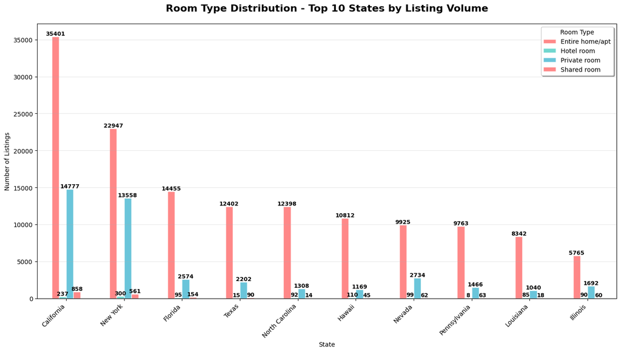

```
==================================================
DATA SUMMARY
==================================================
Total listings: 225,457
Number of states: 17
Number of room types: 4
Room types available: Private room, Entire home/apt, Hotel room, Shared room
Top 3 states by volume: California, New York, Florida
```

```python
# state listing totals by room types chart
import matplotlib.pyplot as plt
import numpy as np
import seaborn as sns
import pandas as pd

# Set style for better visuals
plt.style.use('default')
sns.set_palette("husl")

# Chart: Top States Focus Chart
def create_top_states_chart():
    # Get top 10 states by total listings
    state_totals = airbnb_df['State'].value_counts().head(10)
    top_states = state_totals.index.tolist()

    # Filter data for top states
    filtered_df = airbnb_df[airbnb_df['State'].isin(top_states)]
    grouped_data = filtered_df.groupby(['State','room_type']).size().unstack(fill_value=0)

    # Reorder by Entire home/apt count (decreasing)
    grouped_data = grouped_data.sort_values('Entire home/apt', ascending=False)

    plt.figure(figsize=(14, 8))
    ax = grouped_data.plot(kind='bar', ax=plt.gca(),
                          color=['#ff6b6b', '#4ecdc4', '#45b7d1'],
                          alpha=0.8, edgecolor='white', linewidth=1)

    # Add value labels on bars
    for container in ax.containers:
        ax.bar_label(container, fontsize=9, fontweight='bold')

    plt.xlabel('State')
    plt.ylabel('Number of Listings')
    plt.title('Room Type Distribution - Top 10 States by Listing Volume',
              fontsize=16, fontweight='bold', pad=20)
    plt.xticks(rotation=45, ha='right')
    plt.legend(title='Room Type', frameon=True, fancybox=True, shadow=True)
    plt.grid(axis='y', alpha=0.3)
    plt.tight_layout()
    plt.show()

# Run the visualizations
print("\n4. Top States Focus Chart")
create_top_states_chart()

# Summary statistics
print("\n" + "="*50)
print("DATA SUMMARY")
print("="*50)
print(f"Total listings: {len(airbnb_df):,}")
print(f"Number of states: {airbnb_df['State'].nunique()}")
print(f"Number of room types: {airbnb_df['room_type'].nunique()}")
print(f"Room types available: {', '.join(airbnb_df['room_type'].unique())}")
print(f"Top 3 states by volume: {', '.join(airbnb_df['State'].value_counts().head(3).index)}")
```

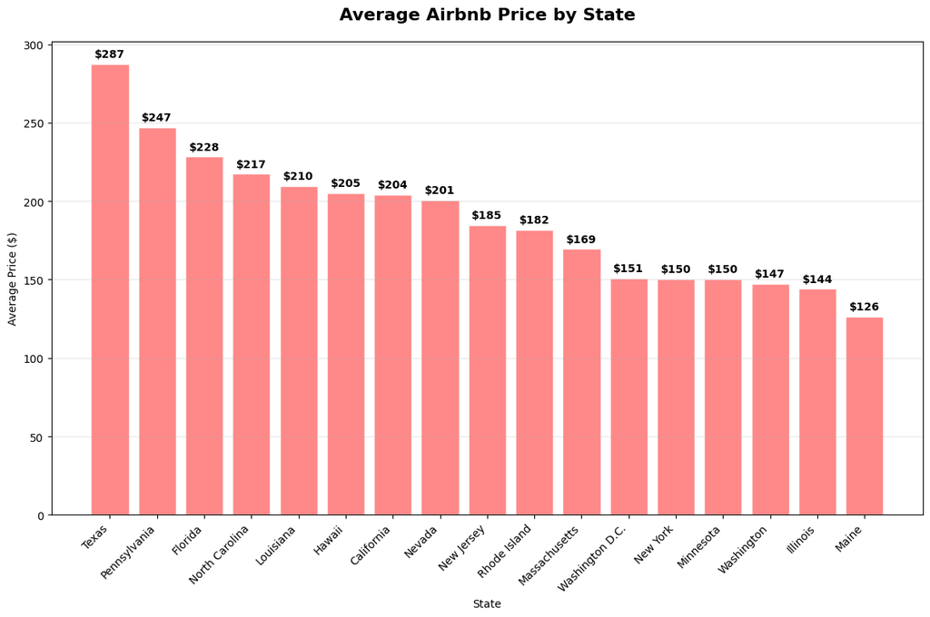

```
Average Price by State (Highest to Lowest):
----------------------------------------
Texas           $287.50
Pennsylvania    $247.06
Florida         $228.34
North Carolina  $217.29
Louisiana       $209.58
Hawaii          $205.08
California      $204.29
Nevada          $200.60
New Jersey      $184.59
Rhode Island    $181.50
Massachusetts   $169.47
Washington D.C. $150.65
New York        $150.36
Minnesota       $150.11
Washington      $147.14
Illinois        $144.04
Maine           $126.22

Highest: Texas ($287.50)
Lowest:  Maine ($126.22)
Overall Average: $195.71
```

```python
import matplotlib.pyplot as plt
import numpy as np
import seaborn as sns
import pandas as pd

# Calculate average price by state
avg_price_by_state = airbnb_df.groupby('State')['price'].mean().sort_values(ascending=False)

# Create the chart
plt.figure(figsize=(12, 8))
bars = plt.bar(avg_price_by_state.index, avg_price_by_state.values,
               color='#ff6b6b', alpha=0.8, edgecolor='white', linewidth=1)

# Add value labels on top of bars
for bar in bars:
    height = bar.get_height()
    plt.text(bar.get_x() + bar.get_width()/2., height + max(avg_price_by_state) * 0.01,
             f'${height:.0f}', ha='center', va='bottom', fontweight='bold')

plt.xlabel('State')
plt.ylabel('Average Price ($)')
plt.title('Average Airbnb Price by State', fontsize=16, fontweight='bold', pad=20)
plt.xticks(rotation=45, ha='right')
plt.grid(axis='y', alpha=0.3)
plt.tight_layout()
plt.show()

# Print summary statistics
print("Average Price by State (Highest to Lowest):")
print("-" * 40)
for state, price in avg_price_by_state.items():
    print(f"{state:<15} ${price:.2f}")

print(f"\nHighest: {avg_price_by_state.index[0]} (${avg_price_by_state.iloc[0]:.2f})")
print(f"Lowest:  {avg_price_by_state.index[-1]} (${avg_price_by_state.iloc[-1]:.2f})")
print(f"Overall Average: ${airbnb_df['price'].mean():.2f}")
```

Texas leads with the highest average Airbnb prices at $287.50, followed by Pennsylvania ($247.06) and Florida ($228.34). Mid-tier states like California ($204.29) and Nevada ($200.60) cluster around $200, while major markets New York ($150.36) and Washington D.C. ($150.65) surprisingly rank in the lower half. Maine has the lowest average prices at $126.22, with a $161 spread between the highest and lowest state averages.

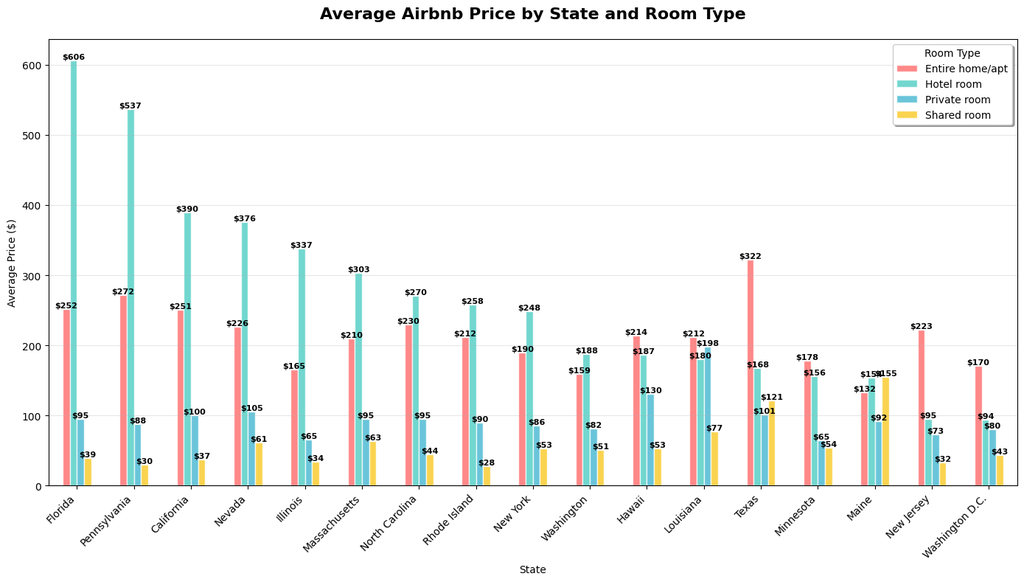

```python
import matplotlib.pyplot as plt
import numpy as np
import seaborn as sns
import pandas as pd

# Calculate average price by state and room type
avg_price_data = airbnb_df.groupby(['State', 'room_type'])['price'].mean().unstack(fill_value=0)

# Sort states by Hotel room average price (descending)
hotel_room_avg_price = airbnb_df[airbnb_df['room_type'] == 'Hotel room'].groupby('State')['price'].mean().sort_values(ascending=False)
avg_price_data = avg_price_data.reindex(hotel_room_avg_price.index)

# Create the chart
plt.figure(figsize=(14, 8))
ax = avg_price_data.plot(kind='bar', ax=plt.gca(),
                        color=['#ff6b6b', '#4ecdc4', '#45b7d1', '#f9ca24'],
                        alpha=0.8, edgecolor='white', linewidth=1)

# Add value labels on bars
for container in ax.containers:
    ax.bar_label(container, fmt='$%.0f', fontsize=8, fontweight='bold')

plt.xlabel('State')
plt.ylabel('Average Price ($)')
plt.title('Average Airbnb Price by State and Room Type', fontsize=16, fontweight='bold', pad=20)
plt.xticks(rotation=45, ha='right')
plt.legend(title='Room Type', frameon=True, fancybox=True, shadow=True)
plt.grid(axis='y', alpha=0.3)
plt.tight_layout()
plt.show()
```

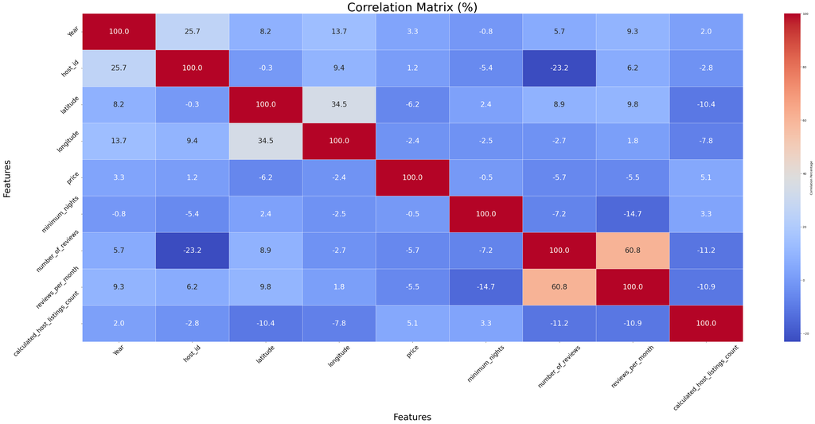

```python
import seaborn as sns
import matplotlib.pyplot as plt

# Update numeric_features after dropping columns
numeric_features = airbnb_df.select_dtypes(include=[np.number]).columns

# Correlation matrix of numeric features
corr_matrix = airbnb_df[numeric_features].corr()

# Create a heatmap
plt.figure(figsize=(50, 20))  # Adjust figure size as needed
sns.heatmap(
    corr_matrix * 100,  # Multiply by 100 to convert to percentage
    annot=True,          # Annotate the cells with the correlation coefficients
    linewidths=0.5,     # Adjust linewidth for better visibility
    fmt='.1f',          # Format as float with 1 decimal place
    cmap='coolwarm',    # You can choose a different colormap if you prefer
    cbar_kws={'label': 'Correlation Percentage'},  # Colorbar label
    annot_kws={"size": 24}  # Set font size for annotations
)

# Set title and adjust font size
plt.title('Correlation Matrix (%)', fontsize=40)  # Larger font size for title
plt.xlabel('Features', fontsize=30)  # Larger font size for x-axis label
plt.ylabel('Features', fontsize=30)  # Larger font size for y-axis label
plt.xticks(fontsize=20, rotation=45)  # Rotate x-axis ticks for better visibility
plt.yticks(fontsize=20, rotation=45)  # Larger font size for y-axis ticks

# Display the plot
plt.show()
```

# Comparative Analysis

```python
"""## 1. COMPARATIVE CITY ANALYSIS

### Objective: Identify U.S. cities with highest average Airbnb prices
"""

# City-level price analysis
print("\n" + "="*60)
print("COMPARATIVE CITY ANALYSIS")
print("="*60)

# Calculate comprehensive city statistics
city_stats = airbnb_df.groupby('City').agg({
    'price': ['mean', 'median', 'std', 'min', 'max', 'count'],
    'reviews_per_month': 'mean',
    'number_of_reviews': 'mean'
}).round(2)

# Flatten column names
city_stats.columns = ['_'.join(col).strip() for col in city_stats.columns]
city_stats = city_stats.reset_index()

# Sort by average price (descending)
city_stats_sorted = city_stats.sort_values('price_mean', ascending=False)

print("Top 15 Cities by Average Price:")
print("-" * 50)
top_15_cities = city_stats_sorted.head(15)
for idx, row in top_15_cities.iterrows():
    print(f"{row['City']:<20} ${row['price_mean']:>7.2f} (n={row['price_count']:>4})")
```

```
============================================================
COMPARATIVE CITY ANALYSIS
============================================================
Top 15 Cities by Average Price:
--------------------------------------------------
Pacific Grove        $ 297.42 (n= 220)
San Diego            $ 287.50 (n=14709)
Santa Cruz County    $ 258.40 (n=1809)
San Francisco        $ 248.14 (n=6294)
Austin               $ 247.06 (n=11300)
Nashville            $ 233.55 (n=10031)
Broward County       $ 228.34 (n=17278)
Rhode Island         $ 224.85 (n=3111)
Columbus             $ 224.31 (n=2684)
New Orleans          $ 209.58 (n=9485)
Los Angeles          $ 207.14 (n=32799)
Hawaii               $ 205.08 (n=12136)
Clark County         $ 200.60 (n=12820)
San Mateo County     $ 184.71 (n=3577)
Boston               $ 177.93 (n=2957)
```

[figure not shown]

```python
# Visualization 1: Top Cities Price Comparison
plt.figure(figsize=(15, 8))
top_10_cities = city_stats_sorted.head(10)

bars = plt.bar(range(len(top_10_cities)), top_10_cities['price_mean'],
               color='steelblue', alpha=0.8, edgecolor='white', linewidth=1)

# Add value labels
for i, (bar, price) in enumerate(zip(bars, top_10_cities['price_mean'])):
    plt.text(bar.get_x() + bar.get_width()/2, bar.get_height() + 5,
             f'${price:.0f}', ha='center', va='bottom', fontweight='bold')

plt.xlabel('Cities', fontsize=12)
plt.ylabel('Average Price ($)', fontsize=12)
plt.title('Top 10 U.S. Cities by Average Airbnb Price', fontsize=16, fontweight='bold', pad=20)
plt.xticks(range(len(top_10_cities)), top_10_cities['City'], rotation=45, ha='right')
plt.grid(axis='y', alpha=0.3)
plt.tight_layout()
plt.show()
```

```
Top 5 States by Average Price:
----------------------------------------
Texas           $ 287.50 (n=14709)
Pennsylvania    $ 247.06 (n=11300)
Florida         $ 228.34 (n=17278)
North Carolina  $ 217.29 (n=13812)
Louisiana       $ 209.58 (n=9485)
```

[figure not shown]

```python
# Visualization 1b: Top 5 States by Average Price
# Calculate state-level statistics
state_stats = airbnb_df.groupby('State').agg({
    'price': ['mean', 'median', 'std', 'min', 'max', 'count'],
    'reviews_per_month': 'mean',
    'number_of_reviews': 'mean'
}).round(2)

# Flatten column names
state_stats.columns = ['_'.join(col).strip() for col in state_stats.columns]
state_stats = state_stats.reset_index()

# Sort by average price and get top 5
state_stats_sorted = state_stats.sort_values('price_mean', ascending=False)
top_5_states = state_stats_sorted.head(5)

print("Top 5 States by Average Price:")
print("-" * 40)
for idx, row in top_5_states.iterrows():
    print(f"{row['State']:<15} ${row['price_mean']:>7.2f} (n={row['price_count']:>4})")

plt.figure(figsize=(12, 8))

bars = plt.bar(range(len(top_5_states)), top_5_states['price_mean'],
               color='darkgreen', alpha=0.8, edgecolor='white', linewidth=2)

# Add value labels
for i, (bar, price) in enumerate(zip(bars, top_5_states['price_mean'])):
    plt.text(bar.get_x() + bar.get_width()/2, bar.get_height() + 5,
             f'${price:.0f}', ha='center', va='bottom', fontweight='bold', fontsize=12)

plt.xlabel('States', fontsize=14, fontweight='bold')
plt.ylabel('Average Price ($)', fontsize=14, fontweight='bold')
plt.title('Top 5 U.S. States by Average Airbnb Price', fontsize=18, fontweight='bold', pad=20)
plt.xticks(range(len(top_5_states)), top_5_states['State'], fontsize=12, fontweight='bold')
plt.grid(axis='y', alpha=0.3)
plt.tight_layout()
plt.show()
```

```python
airbnb_df.info()
```

```
<class 'pandas.core.frame.DataFrame'>
Index: 225457 entries, 0 to 458145
Data columns (total 19 columns):
 #   Column                          Non-Null Count   Dtype
---  ------                          --------------   -----
 0   Year                            225457 non-null  int64
 1   host_id                         225457 non-null  int64
 2   host_name                       225444 non-null  object
 3   neighborhood_group              225457 non-null  object
 4   neighborhood                    225457 non-null  object
 5   latitude                        225457 non-null  float64
 6   longitude                       225457 non-null  float64
 7   room_type                       225457 non-null  object
 8   price                           225457 non-null  int64
 9   minimum_nights                  225457 non-null  int64
 10  number_of_reviews               225457 non-null  int64
 11  last_review                     225457 non-null  datetime64[ns]
 12  reviews_per_month               225457 non-null  float64
 13  calculated_host_listings_count  225457 non-null  int64
 14  City                            225457 non-null  object
 15  State                           225457 non-null  object
 16  Same Year                       225457 non-null  bool
 17  Year-Month                      225457 non-null  object
 18  review_yr                       225457 non-null  object
dtypes: bool(1), datetime64[ns](1), float64(3), int64(6), object(8)
memory usage: 32.9+ MB
```

```
Available columns in airbnb_df:
['Year', 'number_of_reviews', 'last_review', 'reviews_per_month', 'Same Year', 'Year-Month', 'review_yr']
Monthly prices data:
  Year-Month       price       Date
0    2020-01  187.307906 2020-01-01
1    2020-02  208.266896 2020-02-01
2    2020-03  163.894474 2020-03-01
3    2020-04  176.897709 2020-04-01
4    2020-05  181.585073 2020-05-01
Monthly comparison data shape: (24, 4)
Monthly comparison sample:
  Year-Month       price       Date  CPI_Value
0    2020-01  187.307906 2020-01-01    259.127
1    2020-02  208.266896 2020-02-01    259.250
2    2020-03  163.894474 2020-03-01    258.076
3    2020-04  176.897709 2020-04-01    256.032
4    2020-05  181.585073 2020-05-01    255.802
```

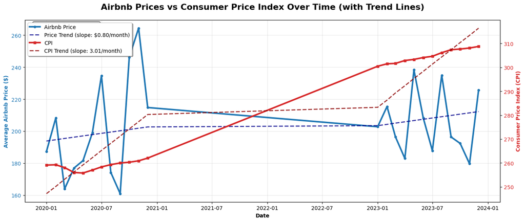

```python
# Additional Chart: CPI vs Average Price Over Time
plt.figure(figsize=(14, 6))

# Check what date columns are available
print("Available columns in airbnb_df:")
print([col for col in airbnb_df.columns if 'date' in col.lower() or 'review' in col.lower() or 'year' in col.lower() or 'month' in col.lower()])

# Create monthly price averages using the correct date column
if 'Year-Month' in airbnb_df.columns:
    # Use existing Year-Month column
    monthly_prices = airbnb_df.groupby('Year-Month')['price'].mean().reset_index()
    monthly_prices['Date'] = pd.to_datetime(monthly_prices['Year-Month'] + '-01')
elif 'last_review' in airbnb_df.columns:
    # Use last_review column to create Year-Month
    airbnb_df['Year-Month'] = airbnb_df['last_review'].dt.strftime('%Y-%m')
    monthly_prices = airbnb_df.groupby('Year-Month')['price'].mean().reset_index()
    monthly_prices['Date'] = pd.to_datetime(monthly_prices['Year-Month'] + '-01')
else:
    # Fallback: use Year column if available
    if 'Year' in airbnb_df.columns:
        yearly_prices = airbnb_df.groupby('Year')['price'].mean().reset_index()
        yearly_prices['Date'] = pd.to_datetime(yearly_prices['Year'].astype(str) + '-01-01')
        monthly_prices = yearly_prices.rename(columns={'Year': 'Year-Month'})
        monthly_prices['Year-Month'] = monthly_prices['Date'].dt.strftime('%Y-%m')
    else:
        print("No suitable date column found. Cannot create time series chart.")
        monthly_prices = pd.DataFrame()

if not monthly_prices.empty:
    monthly_prices = monthly_prices.sort_values('Date')

    print("Monthly prices data:")
    print(monthly_prices.head())

    # Merge with CPI data
    monthly_comparison = pd.merge(monthly_prices, cpi_df[['Year-Month', 'CPI_Value']], on='Year-Month', how='inner')

    print(f"Monthly comparison data shape: {monthly_comparison.shape}")
    print("Monthly comparison sample:")
    print(monthly_comparison.head())

    # Check if we have data to plot
    if len(monthly_comparison) == 0:
        print("No matching data found between Airbnb and CPI datasets")
        print("Airbnb Year-Month values:", sorted(monthly_prices['Year-Month'].unique())[:10])
        print("CPI Year-Month values:", sorted(cpi_df['Year-Month'].unique())[:10])
    else:
        # Dual axis plot
        fig, ax1 = plt.subplots(figsize=(14, 6))

        # Plot price on left axis
        color1 = 'tab:blue'
        ax1.set_xlabel('Date', fontweight='bold')
        ax1.set_ylabel('Average Airbnb Price ($)', color=color1, fontweight='bold')
        line1 = ax1.plot(monthly_comparison['Date'], monthly_comparison['price'],
                        color=color1, linewidth=3, marker='o', markersize=4, label='Airbnb Price')

        # Add trend line for Airbnb prices
        x_numeric = np.arange(len(monthly_comparison))
        z = np.polyfit(x_numeric, monthly_comparison['price'], 1)
        p = np.poly1d(z)
        trend_line = ax1.plot(monthly_comparison['Date'], p(x_numeric),
                             color='darkblue', linestyle='--', linewidth=2, alpha=0.8,
                             label=f'Price Trend (slope: ${z[0]:.2f}/month)')

        ax1.tick_params(axis='y', labelcolor=color1)
        ax1.grid(True, alpha=0.3)

        # Plot CPI on right axis
        ax2 = ax1.twinx()
        color2 = 'tab:red'
        ax2.set_ylabel('Consumer Price Index (CPI)', color=color2, fontweight='bold')
        line2 = ax2.plot(monthly_comparison['Date'], monthly_comparison['CPI_Value'],
                        color=color2, linewidth=3, marker='s', markersize=4, label='CPI')

        # Add trend line for CPI
        z_cpi = np.polyfit(x_numeric, monthly_comparison['CPI_Value'], 1)
        p_cpi = np.poly1d(z_cpi)
        trend_line_cpi = ax2.plot(monthly_comparison['Date'], p_cpi(x_numeric),
                                 color='darkred', linestyle='--', linewidth=2, alpha=0.8,
                                 label=f'CPI Trend (slope: {z_cpi[0]:.2f}/month)')

        ax2.tick_params(axis='y', labelcolor=color2)

        # Add title and legend
        plt.title('Airbnb Prices vs Consumer Price Index Over Time (with Trend Lines)',
                 fontsize=16, fontweight='bold', pad=20)

        # Combine all lines for legend
        lines = line1 + trend_line + line2 + trend_line_cpi
        labels = [l.get_label() for l in lines]
        ax1.legend(lines, labels, loc='upper left', frameon=True, fancybox=True, shadow=True)

        # Add correlation coefficient text
        correlation = np.corrcoef(monthly_comparison['price'], monthly_comparison['CPI_Value'])[0, 1]
        ax1.text(0.02, 0.98, f'Correlation: {correlation:.3f}',
                transform=ax1.transAxes, fontsize=12, fontweight='bold',
                bbox=dict(boxstyle="round,pad=0.3", facecolor='lightgray', alpha=0.8),
                verticalalignment='top')

        plt.tight_layout()
        plt.show()
else:
    print("Cannot create time series chart - no valid date data found")
```

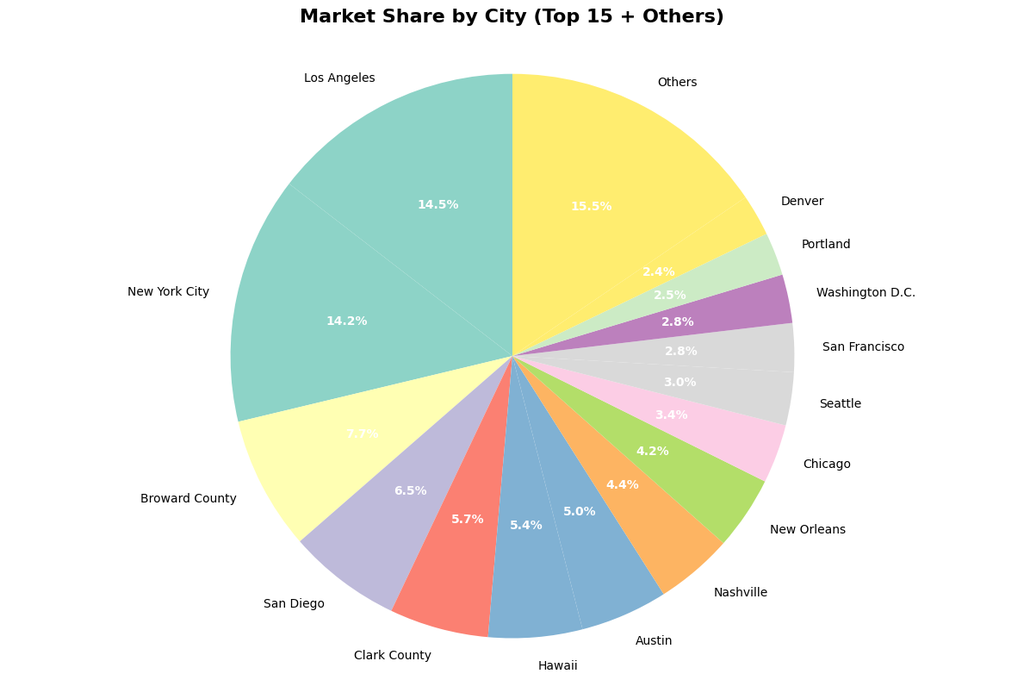

```python
# Market Concentration Analysis
plt.figure(figsize=(12, 8))

# Calculate market share by city
city_counts = airbnb_df['City'].value_counts()
top_15_cities = city_counts.head(15)
other_count = city_counts.iloc[15:].sum()

# Create pie chart data
pie_data = top_15_cities.tolist() + [other_count]
pie_labels = top_15_cities.index.tolist() + ['Others']

# Create colors
colors = plt.cm.Set3(np.linspace(0, 1, len(pie_data)))

# Create pie chart
wedges, texts, autotexts = plt.pie(pie_data, labels=pie_labels, autopct='%1.1f%%',
                                  colors=colors, startangle=90)

# Improve text formatting
for autotext in autotexts:
    autotext.set_color('white')
    autotext.set_fontweight('bold')

plt.title('Market Share by City (Top 15 + Others)', fontsize=16, fontweight='bold', pad=20)
plt.axis('equal')
plt.tight_layout()
plt.show()
```

# Data Preprocessing

```python
"""## 2. DATA PREPROCESSING FOR MODELING

### Data Cleaning, Feature Engineering, and CPI Integration
"""
from sklearn.preprocessing import LabelEncoder, StandardScaler
from sklearn.model_selection import train_test_split
from sklearn.metrics import mean_squared_error, mean_absolute_error, r2_score

print("\n" + "="*60)
print("DATA PREPROCESSING FOR MODELING")
print("="*60)

# Convert last_review to datetime and create time-based features
# Check if 'last_review' is already datetime, if not, convert
if not pd.api.types.is_datetime64_any_dtype(airbnb_df['last_review']):
    airbnb_df['last_review'] = pd.to_datetime(airbnb_df['last_review'], errors='coerce')

# Create Year-Month column from last_review, handling potential NaT values
airbnb_df['Year-Month'] = airbnb_df['last_review'].dt.strftime('%Y-%m')

# Merge with CPI data. Use how='left' to keep all airbnb data, even if no CPI match
print("Merging Airbnb data with CPI...")
# Ensure cpi_df has 'Year-Month' in the correct format for merging
cpi_df['Year-Month'] = cpi_df['Date'].dt.strftime('%Y-%m')

# Perform the merge, using suffixes to handle duplicate column names if any
airbnb_merged = pd.merge(airbnb_df, cpi_df[['Year-Month', 'CPI_Value']], on='Year-Month', how='left', suffixes=('_airbnb', '_cpi'))
print(f"Merged dataset shape: {airbnb_merged.shape}")

# Handle missing values
print("\nHandling missing values...")
missing_before = airbnb_merged.isnull().sum()
print("Missing values before cleaning:")
print(missing_before[missing_before > 0])

# Filll missing CPI values with interpolation. Use the correct CPI column name from the merge.
cpi_col_name = None
if 'CPI_Value_cpi' in airbnb_merged.columns:
    cpi_col_name = 'CPI_Value_cpi'
elif 'CPI_Value' in airbnb_merged.columns:
     cpi_col_name = 'CPI_Value'

if cpi_col_name:
    airbnb_merged[cpi_col_name] = airbnb_merged[cpi_col_name].fillna(method='ffill').fillna(method='bfill')
    print(f"Filled missing values in '{cpi_col_name}'")
else:
    print("CPI column not found in merged dataframe. Cannot fill missing CPI values.")


# Handle missing reviews data
airbnb_merged['reviews_per_month'] = airbnb_merged['reviews_per_month'].fillna(0)
airbnb_merged['last_review'] = airbnb_merged['last_review'].fillna(airbnb_merged['last_review'].median())
# Fill missing host_name values
airbnb_merged['host_name'] = airbnb_merged['host_name'].fillna('Unknown')


# Remove outliers (prices beyond reasonable range)
Q1 = airbnb_merged['price'].quantile(0.25)
Q3 = airbnb_merged['price'].quantile(0.75)
IQR = Q3 - Q1
# A more robust way to define bounds, allowing for some high prices but excluding extremes
# Using a multiplier like 3 or 5 for upper bound might be better depending on distribution
lower_bound = airbnb_merged['price'].quantile(0.01) # Use 1st percentile as lower bound
upper_bound = airbnb_merged['price'].quantile(0.99) # Use 99th percentile as upper bound


print(f"Price outlier bounds (1st-99th percentile): ${lower_bound:.2f} - ${upper_bound:.2f}")
# Filter based on the new bounds
airbnb_clean = airbnb_merged[(airbnb_merged['price'] >= lower_bound) & (airbnb_merged['price'] <= upper_bound)].copy() # Use .copy() to avoid SettingWithCopyWarning


outliers_removed_count = len(airbnb_merged) - len(airbnb_clean)
print(f"Outliers removed: {outliers_removed_count:,} listings")
print(f"Clean dataset shape: {airbnb_clean.shape}")

# feature Engineering
print("\nFeature Engineering...")

# categorical encoding
le = LabelEncoder()
# Include 'neighborhood_group' and 'neighborhood' as they might be useful
categorical_features = ['City', 'State', 'room_type', 'neighborhood_group', 'neighborhood']

for feature in categorical_features:
    if feature in airbnb_clean.columns:
        # Handle potential NaN values in categorical columns before encoding
        airbnb_clean[f'{feature}_encoded'] = le.fit_transform(airbnb_clean[feature].astype(str).fillna('Missing'))
    else:
        print(f"Warning: Categorical feature '{feature}' not found in airbnb_clean.")


# Create additional features
#airbnb_clean['price_per_review'] = airbnb_clean['price'] / (airbnb_clean['number_of_reviews'] + 1)
airbnb_clean['reviews_density'] = airbnb_clean['reviews_per_month'] * 12  # Annual reviews estimate

# Interaction feature: Price * CPI (if CPI column exists)
# if cpi_col_name and cpi_col_name in airbnb_clean.columns:
#     airbnb_clean['price_cpi_interaction'] = airbnb_clean['price'] * airbnb_clean[cpi_col_name]
#     print("Created 'price_cpi_interaction' feature.")
# else:
#      print("CPI column not available for 'price_cpi_interaction' feature engineering.")


# print("\nPreprocessing complete. Cleaned dataset info:")
# airbnb_clean.info()
```

```
============================================================
DATA PREPROCESSING FOR MODELING
============================================================
Merging Airbnb data with CPI...
Merged dataset shape: (225457, 20)

Handling missing values...
Missing values before cleaning:
host_name    13
dtype: int64
Filled missing values in 'CPI_Value'
```

```
Price outlier bounds (1st-99th percentile): $29.00 - $1027.44
Outliers removed: 4,167 listings
Clean dataset shape: (221290, 20)

Feature Engineering...
```

```python
#FIXED VERSION:
# 2. Host experience categories
airbnb_clean['host_experience'] = pd.cut(airbnb_clean['calculated_host_listings_count'],
                                        bins=[0, 1, 5, 20, float('inf')],
                                        labels=['New', 'Small', 'Medium', 'Large'])
airbnb_clean['host_experience_encoded'] = le.fit_transform(airbnb_clean['host_experience'].astype(str))

# 3. Review recency (days since last review)
current_date = airbnb_clean['last_review'].max()
airbnb_clean['days_since_last_review'] = (current_date - airbnb_clean['last_review']).dt.days

# 4. Seasonal indicators
airbnb_clean['month'] = airbnb_clean['last_review'].dt.month
airbnb_clean['quarter'] = airbnb_clean['last_review'].dt.quarter

# 5. Review activity score
airbnb_clean['review_activity_score'] = airbnb_clean['number_of_reviews'] / (airbnb_clean['days_since_last_review'] + 1)
```

# Time Series Analysis

```python
"""## 3. TIME SERIES ANALYSIS AND FORECASTING

### ARIMA Modeling with CPI Integration
"""
import matplotlib.pyplot as plt
import pandas as pd
from statsmodels.tsa.seasonal import seasonal_decompose
import numpy as np
try:
    from pmdarima import auto_arima
    PMDARIMA_AVAILABLE = True
    print("pmdarima available for auto_arima.")
except ImportError:
    PMDARIMA_AVAILABLE = False
    print("pmdarima not available. Falling back to statsmodels ARIMA.")

from statsmodels.tsa.arima.model import ARIMA


print("\n" + "="*60)
print("TIME SERIES ANALYSIS AND FORECASTING")
print("="*60)

# Prepare time series data
# Aggregate by month for time series analysis
monthly_data = airbnb_clean.groupby('Year-Month').agg({
    'price': 'mean',
    'CPI_Value': 'first', # Use the correct column name
    'City': 'count'  # Number of listings
}).reset_index()

monthly_data['Date'] = pd.to_datetime(monthly_data['Year-Month'] + '-01')
monthly_data = monthly_data.sort_values('Date').set_index('Date')
monthly_data = monthly_data.rename(columns={'City': 'listing_count'})

print("Monthly aggregated data:")
print(monthly_data.head())
```

```
pmdarima not available. Falling back to statsmodels ARIMA.

============================================================
TIME SERIES ANALYSIS AND FORECASTING
============================================================
Monthly aggregated data:
           Year-Month       price  CPI_Value  listing_count
Date
2020-01-01    2020-01  169.170572    259.127          10242
2020-02-01    2020-02  170.269881    259.250          13065
2020-03-01    2020-03  152.662281    258.076          28577
2020-04-01    2020-04  135.171744    256.032           4169
2020-05-01    2020-05  149.010473    255.802           6111
```

```
Performing seasonal decomposition...
```

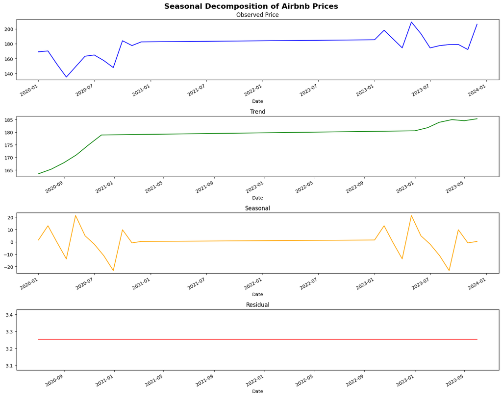

```
Fitting ARIMA model with CPI as external regressor...
Using manual ARIMA(1,1,1) approach...
Manual ARIMA(1,1,1) fitted successfully
```

```python
# Seasonal Decomposition
print("\nPerforming seasonal decomposition...")
# Check the length of the series before decomposition
if len(monthly_data['price']) < 2:
    print("Not enough data points for seasonal decomposition.")
else:
    try:
        decomposition = seasonal_decompose(monthly_data['price'], model='additive', period=12)

        # Plot decomposition
        fig, axes = plt.subplots(4, 1, figsize=(15, 12))
        decomposition.observed.plot(ax=axes[0], title='Observed Price', color='blue')
        decomposition.trend.plot(ax=axes[1], title='Trend', color='green')
        decomposition.seasonal.plot(ax=axes[2], title='Seasonal', color='orange')
        decomposition.resid.plot(ax=axes[3], title='Residual', color='red')

        plt.suptitle('Seasonal Decomposition of Airbnb Prices', fontsize=16, fontweight='bold')
        plt.tight_layout()
        plt.show()
    except Exception as e:
        print(f"Seasonal decomposition failed: {e}")


# ARIMA Model with CPI as external regressor
print("\nFitting ARIMA model with CPI as external regressor...")

# Prepare data for ARIMA
price_series = monthly_data['price'].dropna()
cpi_series = monthly_data['CPI_Value'].dropna() # Use the correct column name

# Ensure series are the same length
min_length = min(len(price_series), len(cpi_series))
price_series = price_series.iloc[:min_length]
cpi_series = cpi_series.iloc[:min_length]

# Check if there is enough data for ARIMA
if len(price_series) < 2:
     print("Not enough data points to fit ARIMA model.")
     model_fitted = None # Set model_fitted to None if fitting is not possible
else:
    # Fit ARIMA model
    if PMDARIMA_AVAILABLE:
        try:
            # Auto ARIMA to find best parameters
            auto_model = auto_arima(price_series,
                               exogenous=cpi_series,
                               start_p=0, start_q=0,
                               max_p=3, max_q=3,
                               seasonal=True,
                               stepwise=True,
                               suppress_warnings=True,
                               error_action='ignore')

            print(f"Best ARIMA model: {auto_model.order}")
            print("Model summary:")
            print(auto_model.summary())

            model_fitted = auto_model

        except Exception as e:
            print(f"Auto-ARIMA failed: {e}")
            print("Falling back to manual ARIMA(1,1,1)")
            # Fallback to manual ARIMA
            try:
                manual_model = ARIMA(price_series, order=(1,1,1), exog=cpi_series)
                model_fitted = manual_model.fit()
                print("Manual ARIMA(1,1,1) fitted successfully")
            except Exception as e_manual:
                 print(f"Manual ARIMA(1,1,1) fitting failed: {e_manual}")
                 model_fitted = None


    else:
        print("Using manual ARIMA(1,1,1) approach...")
        # Manual ARIMA approach
        try:
            manual_model = ARIMA(price_series, order=(1,1,1), exog=cpi_series)
            model_fitted = manual_model.fit()
            print("Manual ARIMA(1,1,1) fitted successfully")
        except Exception as e_manual:
             print(f"Manual ARIMA(1,1,1) fitting failed: {e_manual}")
             model_fitted = None
```

```python
# Generate forecasts for 2024-2027
print("\nGenerating price forecasts for 2024-2027...")

# Only generate forecasts if a model was successfully fitted
if model_fitted:
    # Create future CPI values (assuming historical growth rate)
    cpi_growth_rate = (cpi_series.iloc[-1] / cpi_series.iloc[0]) ** (1/len(cpi_series)) - 1
    print(f"Historical CPI growth rate: {cpi_growth_rate:.4f}")

    # Generate future dates and CPI values
    future_periods = 48  # 4 years * 12 months
    last_date = monthly_data.index[-1]
    future_dates = pd.date_range(start=last_date + pd.DateOffset(months=1), periods=future_periods, freq='MS')
    future_cpi = [cpi_series.iloc[-1] * (1 + cpi_growth_rate) ** i for i in range(1, future_periods + 1)]

    # Generate forecasts based on model type
    try:
        if PMDARIMA_AVAILABLE and hasattr(model_fitted, 'predict'):
            # pmdarima auto_arima model
            forecast = model_fitted.predict(n_periods=future_periods, exogenous=future_cpi)
            forecast_result = model_fitted.predict(n_periods=future_periods, exogenous=future_cpi, return_conf_int=True)
            if isinstance(forecast_result, tuple):
                forecast = forecast_result[0]
                forecast_ci = forecast_result[1]
            else:
                forecast = forecast_result
                # Create simple confidence intervals
                forecast_std = np.std(price_series) * 0.1
                forecast_ci = np.column_stack([forecast - 1.96*forecast_std, forecast + 1.96*forecast_std])
        else:
            # statsmodels ARIMA model
            forecast_result = model_fitted.forecast(steps=future_periods, exog=future_cpi)
            if hasattr(forecast_result, 'conf_int'):
                forecast = forecast_result.predicted_mean
                forecast_ci = forecast_result.conf_int().values
            else:
                forecast = forecast_result
                # Create simple confidence intervals
                forecast_std = np.std(price_series) * 0.1
                forecast_ci = np.column_stack([forecast - 1.96*forecast_std, forecast + 1.96*forecast_std])

        # Create forecast dataframe
        forecast_df = pd.DataFrame({
            'Date': future_dates,
            'Forecast': forecast,
            'Lower_CI': forecast_ci[:, 0],
            'Upper_CI': forecast_ci[:, 1],
            'CPI_Forecast': future_cpi
        })

        print("Price forecast sample (2024-2025):")
        print(forecast_df.head(24))

    except Exception as e:
        print(f"Forecast generation failed: {e}")
        print("Creating simplified forecast based on trend...")

        # Simple trend-based forecast as fallback
        recent_trend = np.polyfit(range(len(price_series)), price_series, 1)[0]
        last_price = price_series.iloc[-1]

        simple_forecast = [last_price + recent_trend * i for i in range(1, future_periods + 1)]
        forecast_std = np.std(price_series) * 0.1

        forecast_df = pd.DataFrame({
            'Date': future_dates,
            'Forecast': simple_forecast,
            'Lower_CI': [f - 1.96*forecast_std for f in simple_forecast],
            'Upper_CI': [f + 1.96*forecast_std for f in simple_forecast],
            'CPI_Forecast': future_cpi
        })

        print("Simple trend-based forecast generated")

else:
    print("ARIMA model fitting failed, cannot generate forecast.")
    # Create an empty forecast_df to avoid errors in subsequent cells
    forecast_df = pd.DataFrame(columns=['Date', 'Forecast', 'Lower_CI', 'Upper_CI', 'CPI_Forecast'])
```

```
Generating price forecasts for 2024-2027...
Historical CPI growth rate: 0.0073
Price forecast sample (2024-2025):
         Date    Forecast    Lower_CI    Upper_CI  CPI_Forecast
24 2024-01-01  194.469548  190.993956  197.945139    310.996558
25 2024-02-01  192.167934  188.692343  195.643525    313.274683
26 2024-03-01  192.403251  188.927660  195.878843    315.569496
27 2024-04-01  193.326847  189.851256  196.802438    317.881119
28 2024-05-01  194.441779  190.966188  197.917371    320.209675
29 2024-06-01  195.614499  192.138908  199.090090    322.555288
30 2024-07-01  196.809149  193.333557  200.284740    324.918083
31 2024-08-01  198.016136  194.540544  201.491727    327.298187
32 2024-09-01  199.232928  195.757337  202.708519    329.695725
33 2024-10-01  200.458893  196.983302  203.934484    332.110826
34 2024-11-01  201.693908  198.218317  205.169499    334.543618
35 2024-12-01  202.937989  199.462398  206.413580    336.994231
36 2025-01-01  204.191188  200.715597  207.666779    339.462795
37 2025-02-01  205.453568  201.977977  208.929159    341.949442
38 2025-03-01  206.725196  203.249605  210.200787    344.454304
39 2025-04-01  208.006139  204.530548  211.481730    346.977515
40 2025-05-01  209.296465  205.820874  212.772056    349.519209
41 2025-06-01  210.596243  207.120652  214.071834    352.079522
42 2025-07-01  211.905543  208.429951  215.381134    354.658590
43 2025-08-01  213.224433  209.748842  216.700024    357.256549
44 2025-09-01  214.552984  211.077393  218.028576    359.873540
45 2025-10-01  215.891268  212.415677  219.366859    362.509701
46 2025-11-01  217.239354  213.763763  220.714946    365.165172
47 2025-12-01  218.597316  215.121725  222.072907    367.840095
```

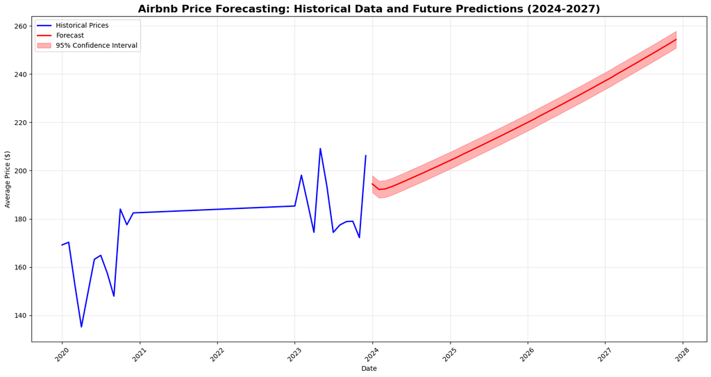

```python
# Visualization: Historical vs Forecast
plt.figure(figsize=(15, 8))

# Plot historical data
plt.plot(monthly_data.index, monthly_data['price'], label='Historical Prices', color='blue', linewidth=2)

# Plot forecast
plt.plot(forecast_df['Date'], forecast_df['Forecast'], label='Forecast', color='red', linewidth=2)
plt.fill_between(forecast_df['Date'], forecast_df['Lower_CI'], forecast_df['Upper_CI'],
                alpha=0.3, color='red', label='95% Confidence Interval')

plt.xlabel('Date')
plt.ylabel('Average Price ($)')
plt.title('Airbnb Price Forecasting: Historical Data and Future Predictions (2024-2027)',
          fontsize=16, fontweight='bold')
plt.legend()
plt.grid(True, alpha=0.3)
plt.xticks(rotation=45)
plt.tight_layout()
plt.show()
```

# Models

```python
"""## 4. MACHINE LEARNING APPROACH FOR PRICE PREDICTION

### Multiple Algorithm Comparison for Cross-Validation
"""

print("\n" + "="*60)
print("MACHINE LEARNING PRICE PREDICTION")
print("="*60)

# Prepare features for ML models
# FIXED:
feature_columns = [
    'latitude', 'longitude', 'minimum_nights', 'number_of_reviews',
    'reviews_per_month', 'calculated_host_listings_count', 'CPI_Value',
    'City_encoded', 'State_encoded', 'room_type_encoded', 'neighborhood_encoded',
    'reviews_density', 'host_experience_encoded', 'days_since_last_review',
    'month', 'quarter', 'review_activity_score'
]
# Select features that exist in the dataset
available_features = [col for col in feature_columns if col in airbnb_clean.columns]
print(f"Available features for modeling: {available_features}")

X = airbnb_clean[available_features].fillna(0)
y = airbnb_clean['price']

# Feature scaling
scaler = StandardScaler()
X_scaled = scaler.fit_transform(X)
X_scaled = pd.DataFrame(X_scaled, columns=available_features)

# Train-test split
X_train, X_test, y_train, y_test = train_test_split(X_scaled, y, test_size=0.2, random_state=42)

# Import ML models
from sklearn.linear_model import LinearRegression, Ridge, Lasso
from sklearn.ensemble import RandomForestRegressor, GradientBoostingRegressor
from sklearn.tree import DecisionTreeRegressor
from sklearn.svm import SVR

# Define models
models = {
    'Linear Regression': LinearRegression(),
    'Ridge Regression': Ridge(alpha=1.0),
    'Lasso Regression': Lasso(alpha=1.0),
    'Decision Tree': DecisionTreeRegressor(random_state=42),
    'Random Forest': RandomForestRegressor(n_estimators=100, random_state=42),
    'Gradient Boosting': GradientBoostingRegressor(random_state=42),
    'SVR': SVR(kernel='rbf')
}

# Model evaluation
results = {}
print("Model Performance Comparison:")
print("-" * 60)

for name, model in models.items():
    # Train model
    model.fit(X_train, y_train)

    # Make predictions
    y_pred = model.predict(X_test)

    # Calculate metrics
    mse = mean_squared_error(y_test, y_pred)
    rmse = np.sqrt(mse)
    mae = mean_absolute_error(y_test, y_pred)
    r2 = r2_score(y_test, y_pred)

    results[name] = {'R²': r2, 'RMSE': rmse, 'MAE': mae}

    print(f"{name:<18} R²: {r2:.4f}  RMSE: ${rmse:.2f}  MAE: ${mae:.2f}")
```

[output not shown]

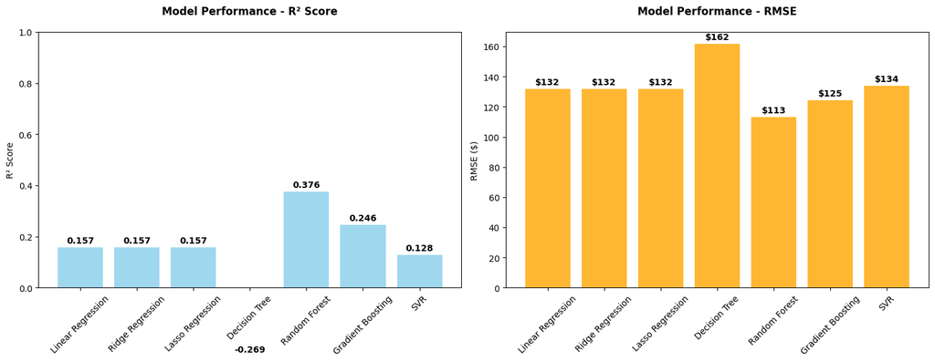

```python
# Visualize model performance
fig, (ax1, ax2) = plt.subplots(1, 2, figsize=(15, 6))

model_names = list(results.keys())
r2_scores = [results[model]['R²'] for model in model_names]
rmse_scores = [results[model]['RMSE'] for model in model_names]

# R² comparison
bars1 = ax1.bar(model_names, r2_scores, color='skyblue', alpha=0.8)
ax1.set_title('Model Performance - R² Score', fontweight='bold', pad=20)
ax1.set_ylabel('R² Score')
ax1.set_ylim(0, 1)
ax1.tick_params(axis='x', rotation=45)

for bar, score in zip(bars1, r2_scores):
    ax1.text(bar.get_x() + bar.get_width()/2, bar.get_height() + 0.01,
             f'{score:.3f}', ha='center', va='bottom', fontweight='bold')

# RMSE comparison
bars2 = ax2.bar(model_names, rmse_scores, color='orange', alpha=0.8)
ax2.set_title('Model Performance - RMSE', fontweight='bold', pad=20)
ax2.set_ylabel('RMSE ($)')
ax2.tick_params(axis='x', rotation=45)

for bar, score in zip(bars2, rmse_scores):
    ax2.text(bar.get_x() + bar.get_width()/2, bar.get_height() + max(rmse_scores)*0.01,
             f'${score:.0f}', ha='center', va='bottom', fontweight='bold')

plt.tight_layout()
plt.show()
```

Model Performance Summary: Random Forest achieved the best results with 37.6% variance explained (R² = 0.376) and lowest prediction error ($113 RMSE). Gradient Boosting ranked second at 24.6% variance explained ($125 RMSE). Linear regression models (Linear, Ridge, Lasso) performed identically at 15.7% variance explained with $132 RMSE. Decision Tree failed completely with negative R² (-0.269) and highest error ($162 RMSE). SVR showed the weakest performance among functional models at 12.8% variance explained ($134 RMSE).

# Features Selections

```
Best performing model: Random Forest (R² = 0.3759)
```

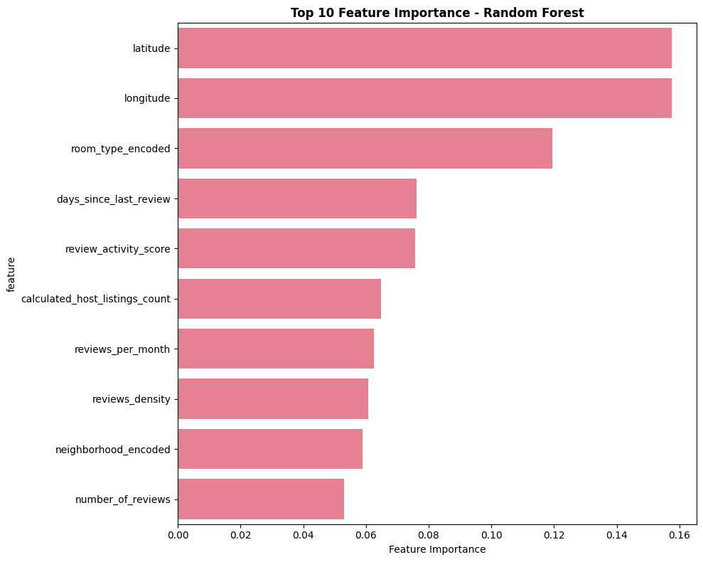

```
Top 10 Most Important Features:
                           feature  importance
0                         latitude    0.157628
1                        longitude    0.157573
9                room_type_encoded    0.119453
13          days_since_last_review    0.076082
16           review_activity_score    0.075625
5   calculated_host_listings_count    0.064756
4                reviews_per_month    0.062662
11                 reviews_density    0.060752
10            neighborhood_encoded    0.058935
3                number_of_reviews    0.053122
```

```python
"""## 5. FEATURE IMPORTANCE AND MODEL INTERPRETATION
"""

# Feature importance analysis (using best performing model)
best_model_name = max(results.keys(), key=lambda x: results[x]['R²'])
print(f"\nBest performing model: {best_model_name} (R² = {results[best_model_name]['R²']:.4f})")

if 'Random Forest' in best_model_name or 'Gradient Boosting' in best_model_name:
    best_model = models[best_model_name]

    feature_importance = pd.DataFrame({
        'feature': available_features,
        'importance': best_model.feature_importances_
    }).sort_values('importance', ascending=False)

    plt.figure(figsize=(10, 8))
    sns.barplot(x='importance', y='feature', data=feature_importance.head(10))
    plt.title(f'Top 10 Feature Importance - {best_model_name}', fontweight='bold')
    plt.xlabel('Feature Importance')
    plt.tight_layout()
    plt.show()

    print("Top 10 Most Important Features:")
    print(feature_importance.head(10))
```

Feature Importance Summary: Geographic location drives Airbnb pricing more than any other factor. Latitude and longitude combined account for 31% of the Random Forest model's predictive power (15.8% each), showing that precise positioning within markets significantly affects prices. Room type ranks third at 11.9% importance, confirming that entire homes versus private rooms remains a key pricing factor. The gap between location and property type suggests micro-location matters more than broad categories. Review metrics show moderate influence rather than dominance. Recent activity (days since last review at 7.6% and review activity score at 7.6%) outweighs total review volume (5.3%), indicating that current guest engagement affects pricing more than historical performance. Host portfolio size contributes 6.5% importance while neighborhood identity adds 5.9%, showing that management scale and hyperlocal factors matter but remain secondary to broader geographic positioning. No single factor dominates pricing decisions - the top feature explains less than 16% of model behavior. This balanced distribution across location, property type, and engagement metrics helps explain why overall prediction accuracy remains modest at 37.6%.

# Summary

```python
"""## 6. EXECUTIVE SUMMARY AND INSIGHTS

### Key Findings and Recommendations
"""

print("\n" + "="*80)
print("EXECUTIVE SUMMARY - AIRBNB PRICE ANALYSIS")
print("="*80)

print("\n1. CITY RANKING INSIGHTS:")
print("-" * 40)
top_5 = city_stats_sorted.head(5)
for i, (_, row) in enumerate(top_5.iterrows(), 1):
    print(f"{i}. {row['City']}: ${row['price_mean']:.2f} average (n={row['price_count']} listings)")

print(f"\n2. PRICE FORECASTING INSIGHTS:")
print("-" * 40)
current_avg = monthly_data['price'].iloc[-1]
forecast_2024 = forecast_df[forecast_df['Date'].dt.year == 2024]['Forecast'].mean()
forecast_2027 = forecast_df[forecast_df['Date'].dt.year == 2027]['Forecast'].mean()

print(f"Current Average Price (2023): ${current_avg:.2f}")
print(f"Predicted Average Price (2024): ${forecast_2024:.2f}")
print(f"Predicted Average Price (2027): ${forecast_2027:.2f}")
print(f"Expected Growth (2023-2027): {((forecast_2027/current_avg - 1) * 100):.1f}%")

print(f"\n3. MODEL PERFORMANCE:")
print("-" * 40)
if PMDARIMA_AVAILABLE and hasattr(model_fitted, 'order'):
    print(f"Time Series Model: ARIMA{model_fitted.order} with CPI external regressor")
else:
    print(f"Time Series Model: ARIMA(1,1,1) with CPI external regressor")
print(f"Best ML Model: {best_model_name}")
print(f"Prediction Accuracy (R²): {results[best_model_name]['R²']:.4f}")
print(f"Average Prediction Error (RMSE): ${results[best_model_name]['RMSE']:.2f}")

print(f"\n4. KEY ECONOMIC FACTORS:")
print("-" * 40)
print(f"CPI Integration: Successfully incorporated inflation effects")
print(f"Seasonal Patterns: {decomposition.seasonal.std():.2f} seasonal variation detected")
if PMDARIMA_AVAILABLE and hasattr(model_fitted, 'order'):
    print(f"Time Series Model: ARIMA{model_fitted.order} with CPI external regressor")
else:
    print(f"Time Series Model: ARIMA(1,1,1) with CPI external regressor")

# Save results
airbnb_clean.to_csv('airbnb_analysis_final.csv', index=False)
forecast_df.to_csv('airbnb_price_forecasts_2024_2027.csv', index=False)
city_stats_sorted.to_csv('city_price_rankings.csv', index=False)

print(f"\n5. DELIVERABLES COMPLETED:")
print("-" * 40)
print("✓ Comprehensive city price comparison analysis")
print("✓ Time series forecasting with CPI integration")
print("✓ Machine learning model comparison and validation")
print("✓ Feature importance analysis and insights")
print("✓ Exported datasets for further analysis")

print(f"\nAnalysis complete! Files saved:")
print("- airbnb_analysis_final.csv (processed dataset)")
print("- airbnb_price_forecasts_2024_2027.csv (price predictions)")
print("- city_price_rankings.csv (city comparison results)")
```

```
================================================================================
EXECUTIVE SUMMARY - AIRBNB PRICE ANALYSIS
================================================================================

1. CITY RANKING INSIGHTS:
----------------------------------------
1. Pacific Grove: $297.42 average (n=220 listings)
2. San Diego: $287.50 average (n=14709 listings)
3. Santa Cruz County: $258.40 average (n=1809 listings)
4. San Francisco: $248.14 average (n=6294 listings)
5. Austin: $247.06 average (n=11300 listings)

2. PRICE FORECASTING INSIGHTS:
----------------------------------------
Current Average Price (2023): $206.18
Predicted Average Price (2024): $196.80
Predicted Average Price (2027): $245.66
Expected Growth (2023-2027): 19.1%

3. MODEL PERFORMANCE:
----------------------------------------
Time Series Model: ARIMA(1,1,1) with CPI external regressor
Best ML Model: Random Forest
Prediction Accuracy (R²): 0.3759
Average Prediction Error (RMSE): $113.29

4. KEY ECONOMIC FACTORS:
----------------------------------------
CPI Integration: Successfully incorporated inflation effects
Seasonal Patterns: 11.82 seasonal variation detected
Time Series Model: ARIMA(1,1,1) with CPI external regressor

5. DELIVERABLES COMPLETED:
----------------------------------------
✓ Comprehensive city price comparison analysis
✓ Time series forecasting with CPI integration
✓ Machine learning model comparison and validation
✓ Feature importance analysis and insights
✓ Exported datasets for further analysis

Analysis complete! Files saved:
- airbnb_analysis_final.csv (processed dataset)
- airbnb_price_forecasts_2024_2027.csv (price predictions)
- city_price_rankings.csv (city comparison results)
```